# Introduction to R

5/29/2019

## What Is R

- R is a widely used language for statistical computing and graphics.
- Completely open source and available for free on multiple platforms
- Provides a wide variety of statistical (linear and nonlinear modelling, classical statistical tests, time-series analysis, classification, clustering, etc.) and graphical techniques
- R in an interpreted language meaning it runs commands directly without needing to be compiled

## Why Use R

- Computers are good at mindless, repetitive tasks and statistics is both!
- Open source
- Easy reproducibility
- Extremely robust statistical packages
  - If you can think of it, there’s probably a package for it
- Makes pretty pictures
- Learning R is learning coding in general

## RStudio

R can be run out of the box, but can feel both basic and difficult at the same time. RStudio is a comprehensive IDE built on top of R that makes using R feel better by keeping various windows organized, introducing new functionality such as Markdown documents, and adding a semi-GUI to R. It’s free and highly used in the R community. It can be downloaded here:

https://www.rstudio.com/

## Using R as a Free Calculator

If you want, R can be just a calculator. Type in any simple mathematical expression to the command prompt, press Enter and see the result

```r
10 + 20
```

```
## [1] 30
```

```r
10/5
```

```
## [1] 2
```

```r
3^3
```

```
## [1] 27
```

Order of operations still matters here

```r
2+5*4
```

```
## [1] 22
```

```r
(2+5)*4
```

```
## [1] 28
```

Sometimes you will need to enclose in multiple parentheses. Make sure they line up exactly where you mean them to.

```r
(4+2)/3^3
```

```
## [1] 0.2222222
```

```r
((4+2)/3)^3
```

```
## [1] 8
```

## Scripts

Commands can be entered directly into the command line, or they can be stored in modified text files called scripts.

Scripts are the basic way coding is done for a few reasons:

- Organization
- Efficiency
- Reproducibility

To create a new script in RStudio, click the page icon in the top left of the GUI and choose R Script

[figure not shown]

## A Very Special “Operator”

In R, one of the best “operators” you can use is `#`. This symbol single-handedly prevents the downfall of civilization. It is the comment symbol and a comment looks like this:

```r
# This is a comment, everything after the # will be ignored
# when the code is running. I can use it to tell future me
# and any other person what is happening at this section.

a <- 1 # I can even put it on a line with an operation.
```

There is an unlimited supply of `#` in R. They are free. Use them everywhere, all the time, and you will save yourself pain and heartache down the line

## Questions?

## Variables

A variable is a kind of label or container for a piece of information. You **assign** values to a variable. The **assignment operator** is the `<-` combination

```r
a <- 1

b <- 2

c <- 3*2
```

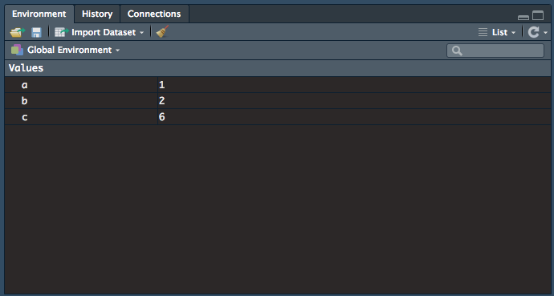

Variables can also be used in arithmetic operations

```r
spikes <- 120
sec <- 20

spikes.per.sec <- spikes/sec

spikes.per.sec
```

```
## [1] 6
```

You can also use a variable to reassign a vale to itself. That’s confusing wording but the code is simple:

```r
a
```

```
## [1] 1
```

```r
a <- a + 5
a
```

```
## [1] 6
```

## A Note on the Assignment Operator

Why `<-` and not `=`?

- `=` works as well! Try it!
- Using `=` instead of `<-` can screw you up when passing variables into functions.
- Just stick with `<-` and it will save you headache

## Rules for Naming Variables

- Can include any alphanumeric character, a period `.`, or an underscore `_`
- Variables are case sensitive. `num` is different from `Num` is different from `NUM`
- Variable names cannot include spaces.
- Variable names must start with a letter or a `.`. Generally starting with a `.` is reserved for special cases though
- Variable names cannot be on of the reserved keywords such as `TRUE`, `if`, `then`, `NaN`, `while`, and more. If you try to assign to a keyword, R will complain so you’ll know pretty quickly

## Tips for Naming Variables

- Names should be informative to what the variable is. Do not use `a`, `b`, `a1`, `var1` etc.
- Be succinct. You can use abbreviations if they are somewhat memorable or you add comments about what they stand for in the code.
- Multiword variables are named using different conventions based on the person.
  - `_` : `example_underscore`
  - `.` : `example.period`
  - Camel case: `exampleCamelCase`

## Questions?

## Functions

Functions are commands that will act on inputs to produce some output.

```r
abs(-21)
```

```
## [1] 21
```

```r
abs(21)
```

```
## [1] 21
```

The standard form of a function is: \(object <- function(input1, input2, ...)\)

Inputs are also known as arguments

Do not try to memorize all the functions. Google is your best friend for remembering and finding functions.

If you don’t remember the exact form of a function, use the help operator `?`

```r
?round
```

Arguments can be specified one of two ways, by location or by name. Let’s use the `round` function as an example

```r
round(3.14159,2)
```

```
## [1] 3.14
```

```r
round(x = 3.14159, digits = 2)
```

```
## [1] 3.14
```

```r
round(digits = 2, x = 3.14159)
```

```
## [1] 3.14
```

```r
round(2,3.14159)
```

```
## [1] 2
```

One of the best things about RStudio is the tab-complete capability. When typing a function (or variable or sometimes file path) name, press tab to bring up a small window with a list of functions containing that string of letters. You can use the up/down arrows to traverse this list. Press tab again when highlighting the function you want to autocomplete it. Practicing this will save time in the long run.

As well as the tab-complete, you can also list out possible arguments for a command after you have finished typing it with parentheses by pressing Tab.

Functions can be called inside other functions

```r
sqrt(abs(-4))
```

```
## [1] 2
```

These are called **nested functions**. `abs()` is nested within the call to `sqrt()`. Functions will always be evaluated from inside to out. You can nest as many functions as you like, but it makes code much more difficult to read. Use nested functions reasonably.

## Creating Vectors

Vectors (a.k.a arrays) are data structures that can store multiple values. All of the values must be the same data type which we will cover soon

You can easily create a vector using the `c()` command which stands for combine.

```r
mice.per.cage <- c(5,6,12,1,14,3,6,8,5,5,9,14,5)

mice.per.cage
```

```
##  [1]  5  6 12  1 14  3  6  8  5  5  9 14  5
```

This vector is now said to contain 13 **elements**. The number in brackets refers to the **index** of the leftmost printed value on that row.

## Indexing

Extracting data from a data structure is vital for anything in R. The basic way of doing this is via the `[]` operator.

```r
# We want the number of mice in cage 6
mice.per.cage[6]
```

```
## [1] 3
```

The number in the `[]` is called an **index**. You told R you wanted the number in the 6th spot in the `mice.per.cage` variable. The output of this can also be stored as a variable

```r
cage.6.pop <- mice.per.cage[6]
```

You can extract multiple indices at a time as well.

```r
mice.per.cage[c(1,2,3,4,5)]
```

```
## [1]  5  6 12  1 14
```

For a sequential number vector changing by 1, you can also use another operator, `:`.

```r
1:5
```

```
## [1] 1 2 3 4 5
```

```r
mice.per.cage[1:5]
```

```
## [1]  5  6 12  1 14
```

## Changing Elements in a Vector

There will be times where you will want to edit specific indices in a vector. To do that, we can use the `<-` and `[]` operators in conjunction.

```r
mice.per.cage[3]
```

```
## [1] 12
```

```r
mice.per.cage[3] <- 2

mice.per.cage[3]
```

```
## [1] 2
```

## Other Vector Operations

Determine the number of elements in a vector:

```r
length(mice.per.cage)
```

```
## [1] 13
```

Alter all elements of a vector:

```r
mice.per.cage*2
```

```
##  [1] 10 12  4  2 28  6 12 16 10 10 18 28 10
```

Now say we were adding mice to each cage, but we aren’t adding the same amount to each cage. R makes it easy to do element-by-element arithmetic:

```r
mice.per.cage
```

```
##  [1]  5  6  2  1 14  3  6  8  5  5  9 14  5
```

```r
mice.added <- c(1,2,1,1,3,6,4,3,8,7,2,4,5)
mice.per.cage + mice.added
```

```
##  [1]  6  8  3  2 17  9 10 11 13 12 11 18 10
```

For element-by-element operations, the vectors need to be the exact same size. This also works for division and multiplication as well without needing special operators.

Functions can also perform their operation on each element of a vector:

```r
sqrt(mice.per.cage)
```

```
##  [1] 2.236068 2.449490 1.414214 1.000000 3.741657 1.732051 2.449490
##  [8] 2.828427 2.236068 2.236068 3.000000 3.741657 2.236068
```

## Questions?

## Basics of Matrices

Matrices are just multidimensional arrays. Matrices can be created with the `cbind`, `rbind`, or `matrix` functions

```r
# cbind concatenates column vectors together
mice.per.cage
```

```
##  [1]  5  6  2  1 14  3  6  8  5  5  9 14  5
```

```r
mice.added
```

```
##  [1] 1 2 1 1 3 6 4 3 8 7 2 4 5
```

```r
mice.mat <- cbind(mice.per.cage,mice.added)
```

```r
mice.mat
```

```
##       mice.per.cage mice.added
##  [1,]             5          1
##  [2,]             6          2
##  [3,]             2          1
##  [4,]             1          1
##  [5,]            14          3
##  [6,]             3          6
##  [7,]             6          4
##  [8,]             8          3
##  [9,]             5          8
## [10,]             5          7
## [11,]             9          2
## [12,]            14          4
## [13,]             5          5
```

Accessing parts of a matrix is similar to vectors, still using the `[]` operator except we are adding another number. Values in a matrices are accessed using a `var[row,col]` format

```r
# Return the element in row 1, column 1.
mice.mat[1,1]
```

```
## mice.per.cage
##             5
```

```r
# Return the element in row 3, column 2.
mice.mat[3,2]
```

```
## mice.added
##          1
```

```r
# Return the elements from rows 1 through 5 in column 2
mice.mat[1:5,2]
```

```
## [1] 1 2 1 1 3
```

```r
# Return elements from rows 2 through 6 in columns 1 and 2
mice.mat[2:6,1:2]
```

```
##      mice.per.cage mice.added
## [1,]             6          2
## [2,]             2          1
## [3,]             1          1
## [4,]            14          3
## [5,]             3          6
```

```r
# Return all rows of the second column by leaving the row field blank
mice.mat[,2]
```

```
##  [1] 1 2 1 1 3 6 4 3 8 7 2 4 5
```

```r
# Same with columns. Return all columns of row 4 by leaving the
# col field blank
mice.mat[4,]
```

```
## mice.per.cage    mice.added
##             1             1
```

## Storing Text Data

At times, you may need to store text data instead of numbers. To denote something as text, you use the `""` operators

```r
greeting <- "hello"
greeting
```

```
## [1] "hello"
```

This is extremely different from:

```r
greeting <- hello
```

As a note, `''` is generally interchangeable with `""`. You can use either one to denote a string

You can create character vectors in the same way as vectors of numbers:

```r
metallica<-c("Lars","James","Jason","Kirk")
metallica
```

```
## [1] "Lars"  "James" "Jason" "Kirk"
```

You can index them exactly the same as well

```r
metallica[2]
```

```
## [1] "James"
```

Functions are data type-specific. For example, you cannot take the square root of `"hello"` or `"Lars"`. There are character-specific functions as well, such as the `nchar()` function which tells us how many characters are in a character string

```r
nchar(metallica[4])
```

```
## [1] 4
```

You can use this function on the entire `metallica` array as well to get the number of characters in each string

```r
nchar(metallica)
```

```
## [1] 4 5 5 4
```

## Logical Values

Logical values tell you whether something is `TRUE` or `FALSE`. These can also be represented as `1` and `0`, respectively. This data type can be created from a variety of commands, but most simply are created when testing if numbers are equal to, greater than, or less than each other which are represented by the `==`, `>`, and `<` operators, respectively.

```r
# Less than
21 < 50
```

```
## [1] TRUE
```

```r
# Greater than
21 > 50
```

```
## [1] FALSE
```

```r
# Equal to
21 == 50
```

```
## [1] FALSE
```

Table of logical operators:

| operation | operator | example input | answer |
| --- | --- | --- | --- |
| less than | `<` | `2 < 3` | `TRUE` |
| less than or equal to | `<=` | `2 <= 3` | `TRUE` |
| greater than | `>` | `2 > 3` | `FALSE` |
| greater than or equal | `>=` | `2 >= 3` | `FALSE` |
| equal to | `==` | `2 == 3` | `FALSE` |
| not equal to | `!=` | `2 != 3` | `TRUE` |

Other important logical operators:

| operation | operator | example input | answer |
| --- | --- | --- | --- |
| not | `!` | `!(1==1)` | `FALSE` |
| or | `\|` | `(1==1) \| (2==3)` | `TRUE` |
| and | `&` | `(1==1) & (2==3)` | `FALSE` |

The `!` operator essentially just switches `TRUE` to `FALSE` and vice-versa. You can use it in conjuntion with commands that return logicals as well.

```r
is.nan(c(2, NaN, 5))
```

```
## [1] FALSE  TRUE FALSE
```

```r
!is.nan(c(2, NaN, 5))
```

```
## [1]  TRUE FALSE  TRUE
```

Up to this point, we have introduced 3 types of data we can store and use in R: numerics, characters (strings), and logicals. There are plenty more, but those are generally the more common types. It is possible to forget what type of variable something is, or when you import data, you will want to make sure R imports variables as the correct types. The `str` and `class` functions work great for this.

```r
class(mice.per.cage)
```

```
## [1] "numeric"
```

```r
str(mice.per.cage)
```

```
##  num [1:13] 5 6 2 1 14 3 6 8 5 5 ...
```

## Logical Indexing

This is an extremely useful tool for pulling out data that meet specific parameters you want. We know logical operator return a vector with `TRUE` and `FALSE`. If we use that output as an index, R will return only the values at the indices corresponding to `TRUE`

For example, say we only wanted the cages of mice with >= 6 mice

```r
ind <- mice.per.cage >= 6
ind
```

```
##  [1] FALSE  TRUE FALSE FALSE  TRUE FALSE  TRUE  TRUE FALSE FALSE  TRUE
## [12]  TRUE FALSE
```

The indices equalling `TRUE` are 2, 5, 7, 8, 11, and 12

```r
mice.per.cage
```

```
##  [1]  5  6  2  1 14  3  6  8  5  5  9 14  5
```

```r
mice.per.cage[ind]
```

```
## [1]  6 14  6  8  9 14
```

```r
mice.per.cage[mice.per.cage >= 6]
```

```
## [1]  6 14  6  8  9 14
```

Logical expressions can be combined with the `&` and `|` operators as seen before. So if we only wanted cages with between 6 and 20 mice:

```r
mice.per.cage >= 6
```

```
##  [1] FALSE  TRUE FALSE FALSE  TRUE FALSE  TRUE  TRUE FALSE FALSE  TRUE
## [12]  TRUE FALSE
```

```r
mice.per.cage <= 20
```

```
##  [1] TRUE TRUE TRUE TRUE TRUE TRUE TRUE TRUE TRUE TRUE TRUE TRUE TRUE
```

```r
mice.per.cage[mice.per.cage >= 6 & mice.per.cage <= 20]
```

```
## [1]  6 14  6  8  9 14
```

Another extremely useful thing about logical indexing is that it can also allow you to count the number of instances your data matches specific parameters. For example, how many cages have more than 5 mice:

```r
sum(mice.per.cage >= 6)
```

```
## [1] 6
```

This is because `TRUE` is treated as a numerical `1` and `FALSE` is treated as a numerical `0`. You are only summing the `1`’s

## Factors

Factors are a special type of variable. They can take the shape of characters or numbers, but don’t necessarily represent either. They represent a classification of the data point. For example, if you have are measuring the difference between treatment and control groups and each group has 5 subjects, a factor variable may look like this:

```r
# Control = 0, Treatment = 1
group <- factor(x = c(0,0,0,0,0,1,1,1,1,1))
group
```

```
##  [1] 0 0 0 0 0 1 1 1 1 1
## Levels: 0 1
```

0 and 1 aren’t entirely descriptive by themselves, so you can add labels to them:

```r
group.2 <- factor(x = c(0,0,0,0,0,1,1,1,1,1),
                  labels = c("Ctrl","Tx"))
group.2
```

```
##  [1] Ctrl Ctrl Ctrl Ctrl Ctrl Tx   Tx   Tx   Tx   Tx
## Levels: Ctrl Tx
```

In fact, just always add labels to factors. Coming back to a data set with 0 and 1 coding gender is frustrating when you don’t remember which is which.

Another important point is that labels are assigned in order. The `factor` function sorts the unique values in your numerical array in ascending order and assigns them in order to the `label` array.

```r
group.3 <- factor(x = c(1,1,1,1,1,0,0,0,0,0),
                  labels = c("Ctrl","Tx"))
group.3
```

```
##  [1] Tx   Tx   Tx   Tx   Tx   Ctrl Ctrl Ctrl Ctrl Ctrl
## Levels: Ctrl Tx
```

So even though `1` comes first in the numerical array, it still is assigned to `Tx` because `0` is first numerically and gets assigned to the first value in the `labels` array, `Ctrl`.

## Questions?

## Data Frames

A data frame is a container data structure for many different variable types relating to a full or partial data set.

The basic organization:

1. Each column is a variable
2. Each row is a sample or individual
3. Each index only contains a single value corresponding to the variable type.

For example, if we are storing information on multiple mice, we could store it as we have done previously:

```r
ID <- factor(c("mouse1","mouse2","mouse3","mouse4","mouse5",
               "mouse6","mouse7","mouse8","mouse9","mouse10"), ordered = TRUE)
age <- c(16,28,19,21,23,20,25,24,27,22)
gender <- factor(c(0,1,1,0,1,0,0,1,1,0), levels = c(0,1),
                 labels = c("F","M"))
weight <- c(25,19,21,19,19,27,22,21,17,22)

age
```

```
##  [1] 16 28 19 21 23 20 25 24 27 22
```

```r
gender
```

```
##  [1] F M M F M F F M M F
## Levels: F M
```

So we would know that age, gender, and weight correspond to each individual mouse, however R would not know to treat them that way. We can instead join them together in a data frame using the `data.frame` command

```r
mouse.df <- data.frame(ID,age,gender,weight)

# Output first 5 rows and all columns of mouse.df
mouse.df[1:5,]
```

```
##       ID age gender weight
## 1 mouse1  16      F     25
## 2 mouse2  28      M     19
## 3 mouse3  19      M     21
## 4 mouse4  21      F     19
## 5 mouse5  23      M     19
```

Accessing data in a data frame can be done in a variety of ways, but the most common is using the `$` operator.

```r
mouse.df$gender
```

```
##  [1] F M M F M F F M M F
## Levels: F M
```

The `[]` operator can also be used in combination with `$` to pull out specific rows of the variable of interest

```r
mouse.df$gender[1:5]
```

```
## [1] F M M F M
## Levels: F M
```

Data frames can be accessed similar to matrices as well

```r
# Using numbers (value in the 1st row, 2nd column)
mouse.df[1,2]
```

```
## [1] 16
```

```r
# Or using names of the variables (all values in the "age" column)
mouse.df[,"age"]
```

```
##  [1] 16 28 19 21 23 20 25 24 27 22
```

As well, changing the original variables outside the data frame DOES NOT change the data inside the data frame after it has been created

```r
age <- c(0,0,0,0,0,0,0,0,0,0)
age
```

```
##  [1] 0 0 0 0 0 0 0 0 0 0
```

```r
mouse.df$age
```

```
##  [1] 16 28 19 21 23 20 25 24 27 22
```

## Other Data Frame Operations

Being able to check the variable types in a data frame after it has been created is important when both importing data or coming back to it after a time. The `str` function is very useful for this

```r
str(mouse.df)
```

```
## 'data.frame':    10 obs. of  4 variables:
##  $ ID    : Ord.factor w/ 10 levels "mouse1"<"mouse10"<..: 1 3 4 5 6 7 8 9 10 2
##  $ age   : num  16 28 19 21 23 20 25 24 27 22
##  $ gender: Factor w/ 2 levels "F","M": 1 2 2 1 2 1 1 2 2 1
##  $ weight: num  25 19 21 19 19 27 22 21 17 22
```

`str` gives a list of all variables, their type, any factor levels, and a small sample of the data.

Providing simple summary statistics for a data frame can also be helpful. This can be done using the `summary()` function

```r
summary(mouse.df)
```

```
##        ID         age        gender     weight
##  mouse1 :1   Min.   :16.00   F:5    Min.   :17.0
##  mouse10:1   1st Qu.:20.25   M:5    1st Qu.:19.0
##  mouse2 :1   Median :22.50          Median :21.0
##  mouse3 :1   Mean   :22.50          Mean   :21.2
##  mouse4 :1   3rd Qu.:24.75          3rd Qu.:22.0
##  mouse5 :1   Max.   :28.00          Max.   :27.0
##  (Other):4
```

This will provide quartiles and means for numeric data as well as counts for factors.

## Dataframe Subset

Most likely, you won’t want to perform operations on all samples of a data frame every time, such as when there are multiple groups in the dataset. Subsetting a dataframe allows you to pick and choose the rows you want, and there are multiple ways to do it.

```r
# Can use logical indexing to grab the mice who are over 4 months old
mouse.df[mouse.df$age > 4,]
```

```
##         ID age gender weight
## 1   mouse1  16      F     25
## 2   mouse2  28      M     19
## 3   mouse3  19      M     21
## 4   mouse4  21      F     19
## 5   mouse5  23      M     19
## 6   mouse6  20      F     27
## 7   mouse7  25      F     22
## 8   mouse8  24      M     21
## 9   mouse9  27      M     17
## 10 mouse10  22      F     22
```

```r
# Can also grab only single variable if necessary
mouse.df[mouse.df$age > 4, "weight"]
```

```
##  [1] 25 19 21 19 19 27 22 21 17 22
```

The basic structure is that `mouse.df$age > 4` is returning an array of 0’s and 1’s to choose rows whereas the `"weight"` is saying which column, or variable, to take values from. Use `c()` to choose multiple variables.

## The `subset` function

Subsetting using `[]` can often become messy and hard to read after the fact. Multiple functions have been created to handle this type of operation in a more readable fashion. The most common one is `subset`

```r
# Mice over 4 months old
subset(x = mouse.df, subset = age > 4)
```

```
##         ID age gender weight
## 1   mouse1  16      F     25
## 2   mouse2  28      M     19
## 3   mouse3  19      M     21
## 4   mouse4  21      F     19
## 5   mouse5  23      M     19
## 6   mouse6  20      F     27
## 7   mouse7  25      F     22
## 8   mouse8  24      M     21
## 9   mouse9  27      M     17
## 10 mouse10  22      F     22
```

When subsetting by multiple conditions, use the logical operators discussed previously. So if you only wanted female mice who were over 4 months old:

```r
# Mice over 4 months old who are female
subset(x = mouse.df, subset = age > 4 & gender == "F")
```

```
##         ID age gender weight
## 1   mouse1  16      F     25
## 4   mouse4  21      F     19
## 6   mouse6  20      F     27
## 7   mouse7  25      F     22
## 10 mouse10  22      F     22
```

Use the `select` option in the subset function to return 1 or more specific variables

```r
# Mice over 4 months old who are female only returning weight
subset(x = mouse.df, subset = age > 4 & gender == "M",
       select = weight)
```

```
##   weight
## 2     19
## 3     21
## 5     19
## 8     21
## 9     17
```

Something important to notice is the data type returned by `subset` as opposed to `[]`.

1. `subset` returns selected output as a dataframe no matter what
2. `[]` will return an array if only a single variable is selected as output.

View output structure from `mouse.df[mouse.df$age > 4, "weight"]` and `subset(mouse.df, age > 4 & gender == "M", select = weight)` for example

## Adding Variables

Adding a variable to a dataframe is simple. Use the `df$<new.var.name>` notation and assign something to it

```r
# Store information on average number of hours each mouse sleeps per day.
mouse.df$avg.sleep <- c(6,8,3,14,2,7,7,8,5,10)
mouse.df
```

```
##         ID age gender weight avg.sleep
## 1   mouse1  16      F     25         6
## 2   mouse2  28      M     19         8
## 3   mouse3  19      M     21         3
## 4   mouse4  21      F     19        14
## 5   mouse5  23      M     19         2
## 6   mouse6  20      F     27         7
## 7   mouse7  25      F     22         7
## 8   mouse8  24      M     21         8
## 9   mouse9  27      M     17         5
## 10 mouse10  22      F     22        10
```

An important note is that any time you add a new variable to a dataframe, all of the data in that variable must be of the same type and must have the same length as the rest of the dataframe. Otherwise an error will occur.

Basic data frame manipulation is supported in base R, however custom functions are available to make life easier in packages.

## Questions?

## Packages

What is a package?

- Collection of functions and data sets grouped under a single name that can be loaded and unloaded from the workspace.
- Fill in gaps in functionality that base R leaves.
- Mainly stored on CRAN making them easily downloaded in RStudio

Thousands of packages exist and they do not come with R when you download the language. Must install the ones you want.

There is a major difference between a package being installed and loaded.

Installed: A package has been downloaded onto the individual’s computer. Does not say anything about whether the components of the package are available to the current R environment. Only done once!

Loaded: Components of a packages are available to the environment after they have been loaded. Have to load a package each time RStudio is opened. Commands for loading packages can be installed at the beginning of scripts

A package must be installed before it can be loaded. A package must be loaded before it can be used.

There are a couple of ways to install a package. RStudio makes the process straightforward using the Packages Window.

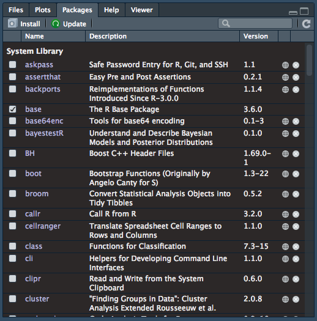

Click the Install button to bring up a new window

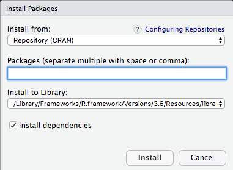

The options describe the following:

1. Whether you are installing from CRAN (the default), or from a downloaded tar.gz file.
2. Either the package name (when downloading from CRAN), or the path to the tar.gz file.
3. Where the package will be installed to on your computer. Defaults to a library in the R program folder

Packages can also be installed using the `install.packages` command.

```r
install.packages("dplyr")
```

Generally easier to use the GUI however, in my experience.

After being installed, packages can be loaded using the `library` command

```r
library(dplyr)
```

Or they can be loaded by clicking the checkbox next to their names in the Packages panel in RStudio

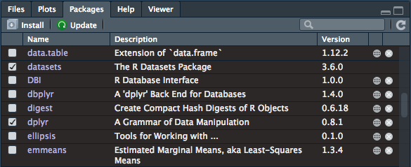

Installed packages should be updated from time to time for bug-fixes and added funcitonality that the authors may have put in. This can be done in a couple of ways

1. Click the Update button in the Packages window. Select the packages to update or select all to update all.
2. The `update.packages()` function

## The tidyverse

The tidyverse is a suite of packages that make data-wrangling much easier overall. It is composed of `dplyr`, `ggplot2`, `tidyr`, and more. You can install the tidyverse suite all at once using the methods from above inserting `tidyverse` into the field for the package name. You can load the tidyverse packages in the same way.

We will only touch on a few of the functions from `dplyr` and `ggplot2` from here on out, but becoming familiar with the other aspects of the tidyverse will improve how you interact with R and your data.